# Red Wine Dataset EDA

## 4.3 探索SO2方面的影响

### （1）游离态SO2

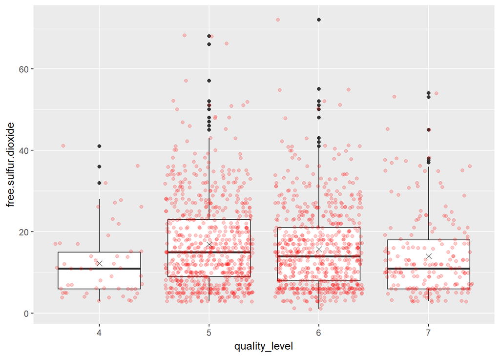

几乎毫无规律。

考虑到前面分析，SO2需要取log，再尝试下。

```
##
##  Pearson's product-moment correlation
##
## data:  red_wine_majority$free.sulfur.dioxide and red_wine_majority$quality
## t = -2.2737, df = 1569, p-value = 0.02312
## alternative hypothesis: true correlation is not equal to 0
## 95 percent confidence interval:
##  -0.106462655 -0.007874346
## sample estimates:
##         cor
## -0.05730821
```

```
##
##  Pearson's product-moment correlation
##
## data:  log(red_wine_majority$free.sulfur.dioxide) and red_wine_majority$quality
## t = -2.2438, df = 1569, p-value = 0.02499
## alternative hypothesis: true correlation is not equal to 0
## 95 percent confidence interval:
##  -0.105715716 -0.007118947
## sample estimates:
##         cor
## -0.05655522
```

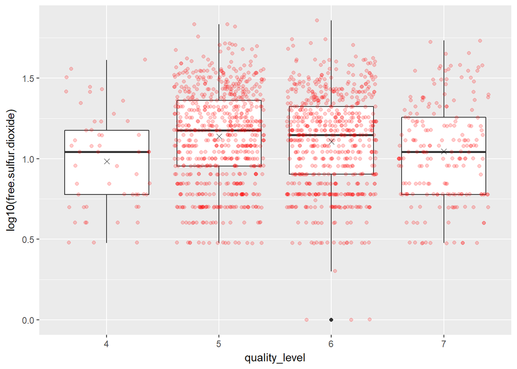

几乎没有任何改进。

### （2）总量SO2

```
##
##  Pearson's product-moment correlation
##
## data:  red_wine_majority$total.sulfur.dioxide and red_wine_majority$quality
## t = -8.2491, df = 1569, p-value = 3.339e-16
## alternative hypothesis: true correlation is not equal to 0
## 95 percent confidence interval:
##  -0.2508077 -0.1559972
## sample estimates:
##        cor
## -0.2038804
```

```
##
##  Pearson's product-moment correlation
##
## data:  log(red_wine_majority$total.sulfur.dioxide) and red_wine_majority$quality
## t = -7.673, df = 1569, p-value = 2.934e-14
## alternative hypothesis: true correlation is not equal to 0
## 95 percent confidence interval:
##  -0.2373981 -0.1420546
## sample estimates:
##        cor
## -0.1901747
```

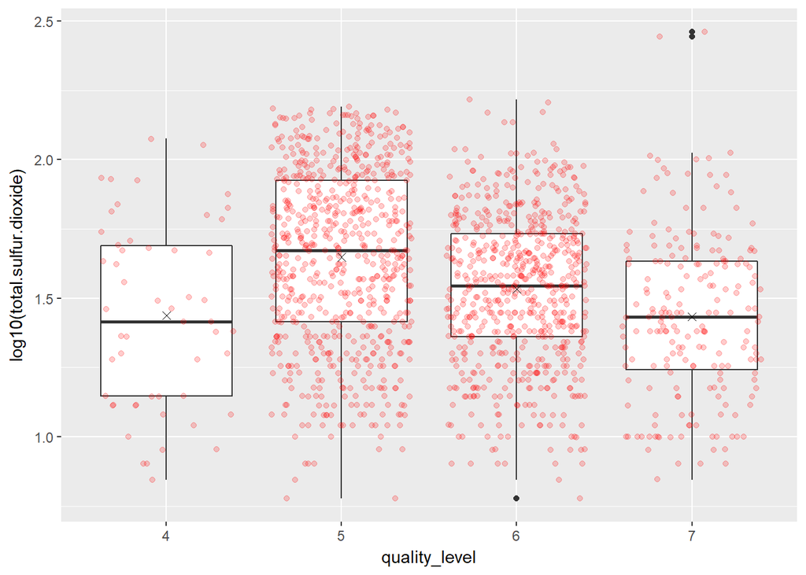

### （3）硫酸盐

```
##
##  Pearson's product-moment correlation
##
## data:  red_wine_majority$sulphates and red_wine_majority$quality
## t = 9.8617, df = 1569, p-value < 2.2e-16
## alternative hypothesis: true correlation is not equal to 0
## 95 percent confidence interval:
##  0.1944593 0.2876118
## sample estimates:
##       cor
## 0.2415921
```

```
##
##  Pearson's product-moment correlation
##
## data:  log(red_wine_majority$sulphates) and red_wine_majority$quality
## t = 12.404, df = 1569, p-value < 2.2e-16
## alternative hypothesis: true correlation is not equal to 0
## 95 percent confidence interval:
##  0.2531343 0.3432324
## sample estimates:
##       cor
## 0.2988492
```

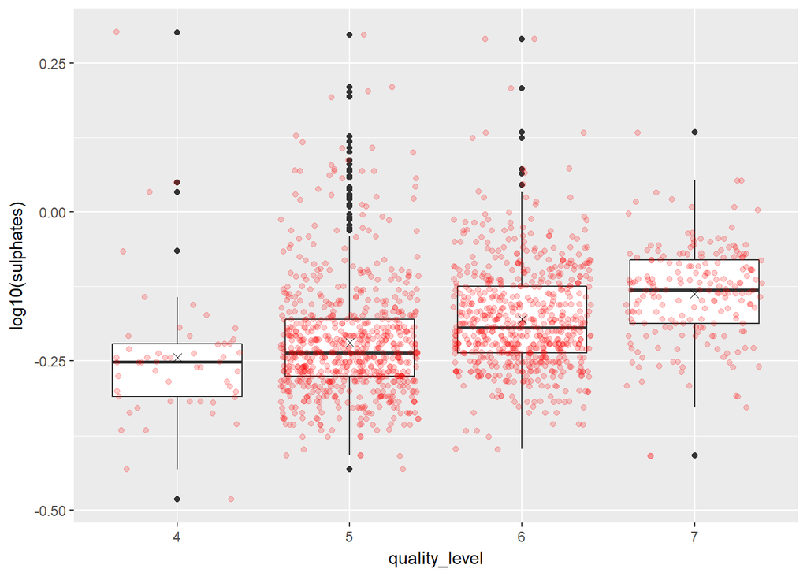

硫酸盐有一定的相关性，同时取log后，相关性有了一定改善，接近0.3。

### （4）小结

只采用取log后的硫酸盐。

## 4.3 探索酒精方面的影响

之前的分析中，酒精是相关性最高的。

```
##
##  Pearson's product-moment correlation
##
## data:  red_wine_majority$alcohol and red_wine_majority$quality
## t = 20.803, df = 1569, p-value < 2.2e-16
## alternative hypothesis: true correlation is not equal to 0
## 95 percent confidence interval:
##  0.4252868 0.5028562
## sample estimates:
##       cor
## 0.4649633
```

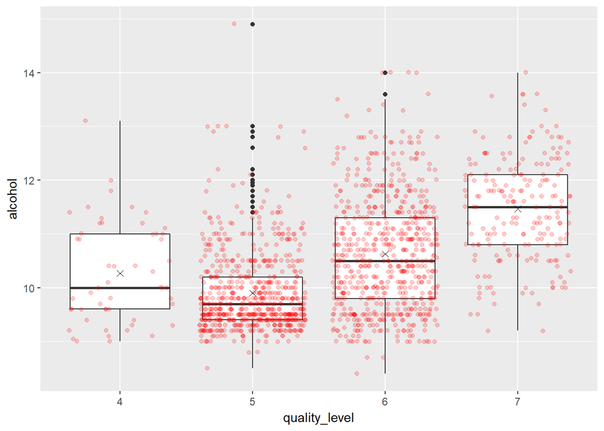

我晕！酒精的图形表达也不咋的。

## 4.4 一个合理的猜测

分析到现在，已经感觉到样本数量不够带来的限制。导致很多分析无法合理解释。

做这个项目做到心累。

据此，我猜测存在这样一种打分方式：专家在打分前心里已经有了5或6分的基本预期，再根据口感，进行微调。而且这种微调具有一（hen）定（qiang）的随机性。

当然，我们还是要相信专家的专业水平。如果以这个为前提，上面采取对大多数酒进行分析的路数就错误了，应该采取第二套方案，研究极端情况。研究到底是什么因素让专家认为，这就是好酒或这就是垃圾。

因此，先找到最好的酒和最差的酒

### （1）新的散点矩阵

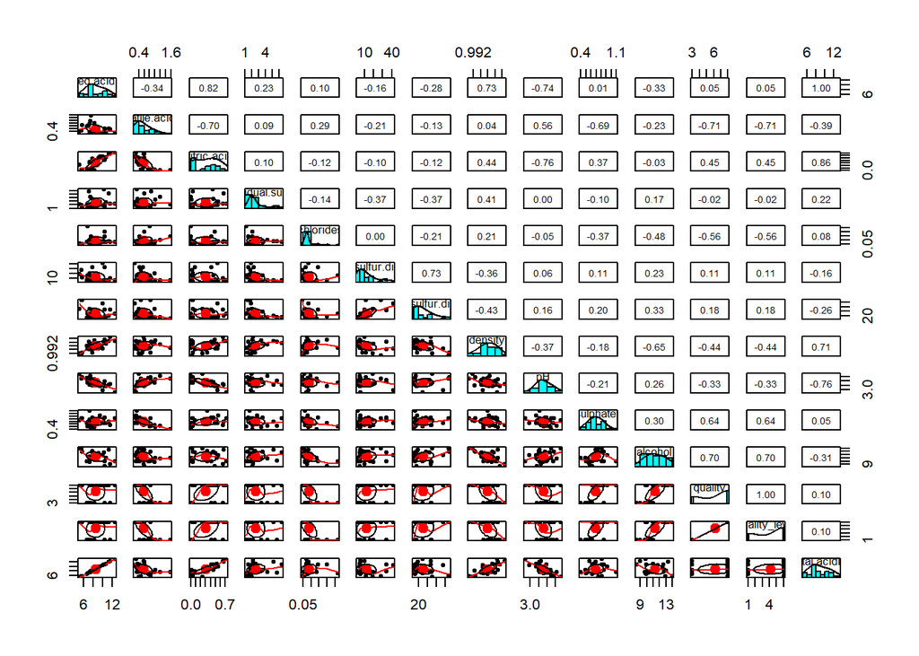

看！相关系数明显上了一个档次。

总体上，和前面的分析一直，主要看**挥发性酸、硫酸盐、酒精**，相关性在0.7左右，可认为是高度相关；

有趣的，盐的相关性达到0.56；

余下的，柠檬酸、密度、ph值的相关性也凸显出来，相关性处于0.3-0.7，有一定相关性。

### (2)几个关键指标的对比

对挥发性酸、硫酸盐、酒精、盐进行比较。

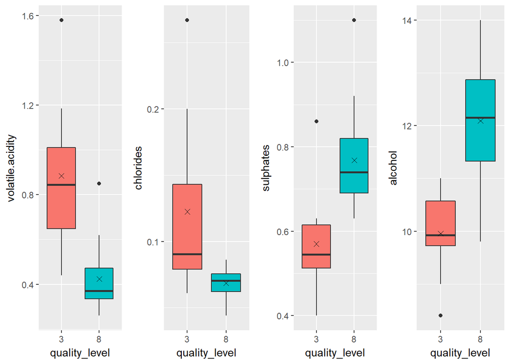

结果表明，好酒、坏酒差异明显。

因此，识别极好或极差的酒，还是有一定规律可循的：

（1）好酒：挥发性酸低、盐低；硫酸盐高、酒精高。

（2）差酒：挥发性酸高、盐较高（没那么明显）；硫酸盐低、酒精低。

有点奇怪：硫酸盐不是影响口感吗？

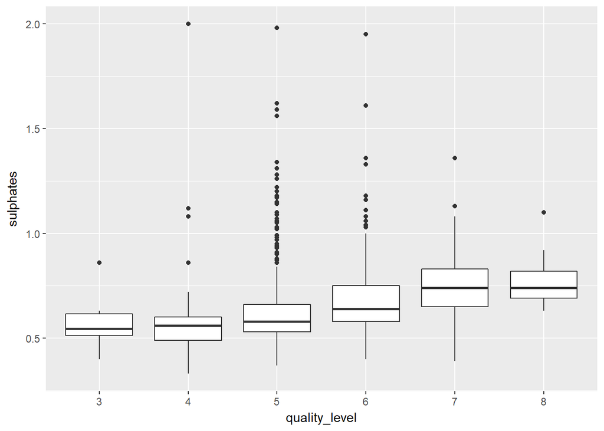

看来硫酸盐这个一般都不会多加，反而有可能由于加太少影响防腐效果从而影响口感。（说得我自己都不相信……）

# 5 Bivariate Analysis

## 5.1 Talk about some of the relationships you observed in this part of the investigation. How did the feature(s) of interest vary with other features in the dataset?

通过全体样本的散点矩阵，可以观察到各指标的两两关系。大部分相关性都很小，低于0.4，Input变量中相关性较强的几对关系是“酒石酸（V1）-柠檬酸（V3）”、“醋酸（V2）-柠檬酸（V3）”、“游离SO2（V6）-总量SO2（V7）”、“酒石酸（V1）-密度（V8）”、“密度（V8）-酒精（V11）”。

与红酒质量最相关的因素依次是：（1）酒精（V11），正相关；（2）醋酸（V2），负相关；（3）硫酸盐（V10），正相关；（4）柠檬酸（V3），正相关。

其他因素影响不大。

上述分析，总体和所查阅到的参考资料一致，但略有差异。例如，理论上最为重要的酒石酸，与品质的关系并不大；还有糖分，该数据集也没表现出什么关系。

## 5.2 Did you observe any interesting relationships between the other features (not the main feature(s) of interest)?

几个酸之间，存在很强的关系。同时，酒石酸是“C位”，柠檬酸是“辅助”，醋酸是“反派”。

游离态SO2和总量SO2，存在很强的关系，但两者与硫酸盐又不太相关。

ph则主要受酸影响，密度主要受酒精和酸影响。

## 5.3 What was the strongest relationship you found?

红酒品质，最强的关系是酒精。

# 6 Multivariate Plots Section

从相关分析中，找出两两相关性比较高，同时和红酒质量也相关的变量。

## 6.1 挥发性酸和非挥发性酸的关系

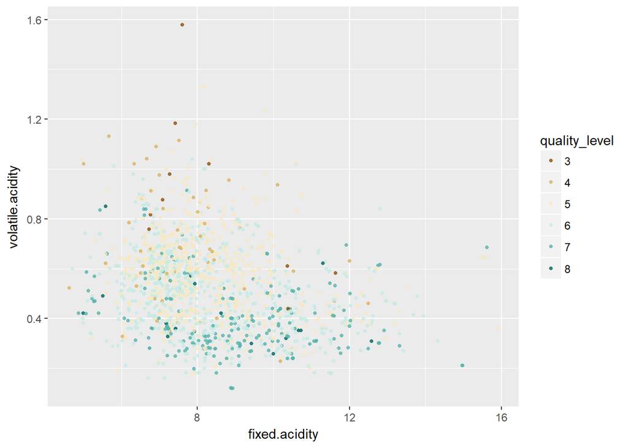

图中展现出一定的层次性，高质量红酒的醋酸总是维持较低值。

## 6.2 ph值和非挥发性酸的关系

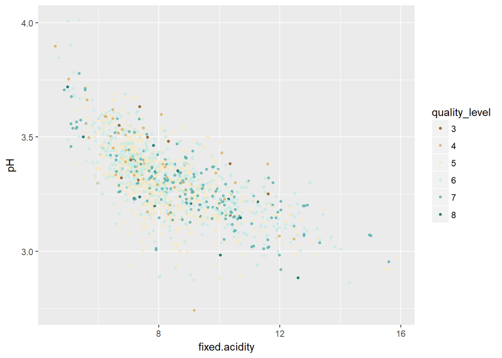

酒石酸和ph值存在明显的相关关系，但不同质量的红酒并没有展现出更多的差异。

## 6.3 三大关键变量和非挥发性酸的关系

分析三大关键因素，即挥发性酸、硫酸盐、酒精与红酒质量的关系。

（1）首先，对连续数据进行分组。考虑到前面单变量分析中酒精是线性下降，尝试对酒精进行分组。依据双变量分析中极好和极坏酒的酒精特征，进行分组。

```
## [1]  8.4 14.9
```

```
##    Min. 1st Qu.  Median    Mean 3rd Qu.    Max.
##   8.400   9.725   9.925   9.955  10.575  11.000
```

```
##    Min. 1st Qu.  Median    Mean 3rd Qu.    Max.
##    9.80   11.32   12.15   12.09   12.88   14.00
```

因此，分组的关键breaks可尝试定为9.9和12.1

（2）其次，进行分组

```
##
##    (8,9.9] (9.9,12.1]  (12.1,15]
##        679        792        128
```

（3）最后，进行4个变量的可视化（挥发性酸、硫酸盐、酒精、红酒质量）

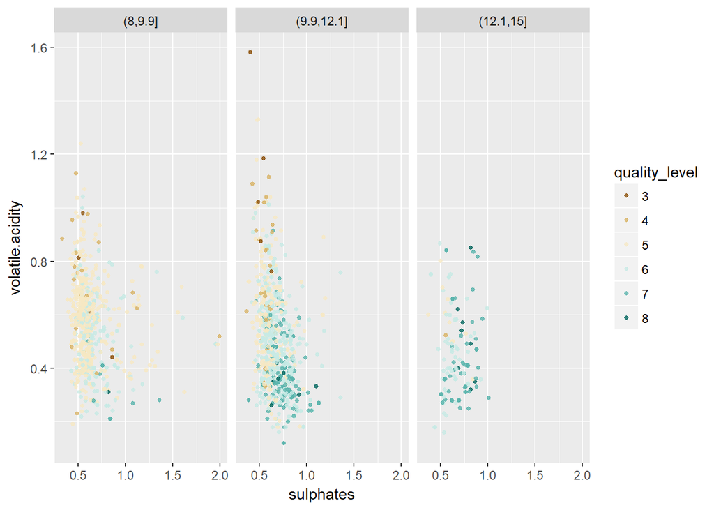

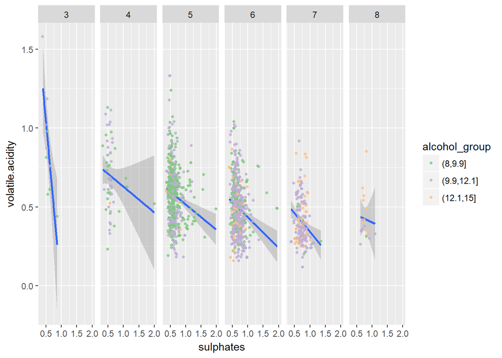

这个可视化方案好像更好一些。

尝试增加分面中的均值点，用点来反映硫酸盐、醋酸的变化趋势，但是未找到完美解决方案。找到的方案基本思路是增加一个数据集，用group_by分组计算硫酸盐、醋酸的均值，再叠加到上图中。

**因此，此问题尚未解决：除了上述较为复杂方法，分面情况下如何对散点进行分组计算？以及，如何将此图做的更美观？**

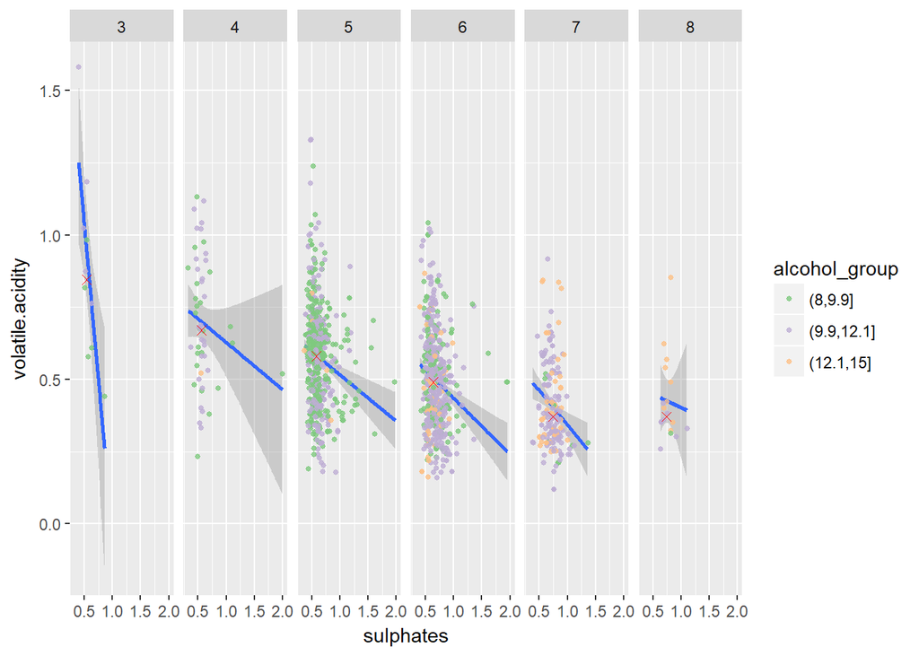

由图可知：

用颜色来识别酒精浓度的影响，显然浓度大的，红酒质量更高；

用分组的统计中值点（红色X）来反映硫酸盐、醋酸与红酒质量的变化关系，显然醋酸越低、硫酸盐越高，红酒质量越高；

| quality_level | sulphates_volatile_r |
| --- | --- |
| 3 | -0.79224058 |
| 4 | -0.17744405 |
| 5 | -0.16692944 |
| 6 | -0.19115595 |
| 7 | -0.22100813 |
| 8 | -0.07200457 |

# 7 Multivariate Analysis

## 7.1 Talk about some of the relationships you observed in this part of the investigation. Were there features that strengthened each other in terms of looking at your feature(s) of interest?

先查看了挥发性酸、非挥发性酸与红酒质量的关系，以及ph值、非挥发性酸与红酒质量的关系。前者有一定规律，而后者几乎没有明显规律。

重点查看了挥发性酸、硫酸盐、酒精这三个主要因素与红酒质量的关系。从图上反映的情况来看，均与红酒质量表现出明显相关性，即酒精浓度越大、醋酸越低、硫酸盐越高，红酒质量就越高。

## 7.2 Were there any interesting or surprising interactions between features?

加入了更多变量，同时表现了挥发性酸、硫酸盐、酒精这三个主要因素与红酒质量的关系。发现斜率变化呈现一定规律，可能有什么样的意义吗？

## OPTIONAL: Did you create any models with your dataset? Discuss the strengths and limitations of your model.

没有建立模型。

# 8 Final Plots and Summary

## 8.1 整体而言，酒精、醋酸、硫酸盐、柠檬酸是决定红酒质量的关键因素

### Plot One

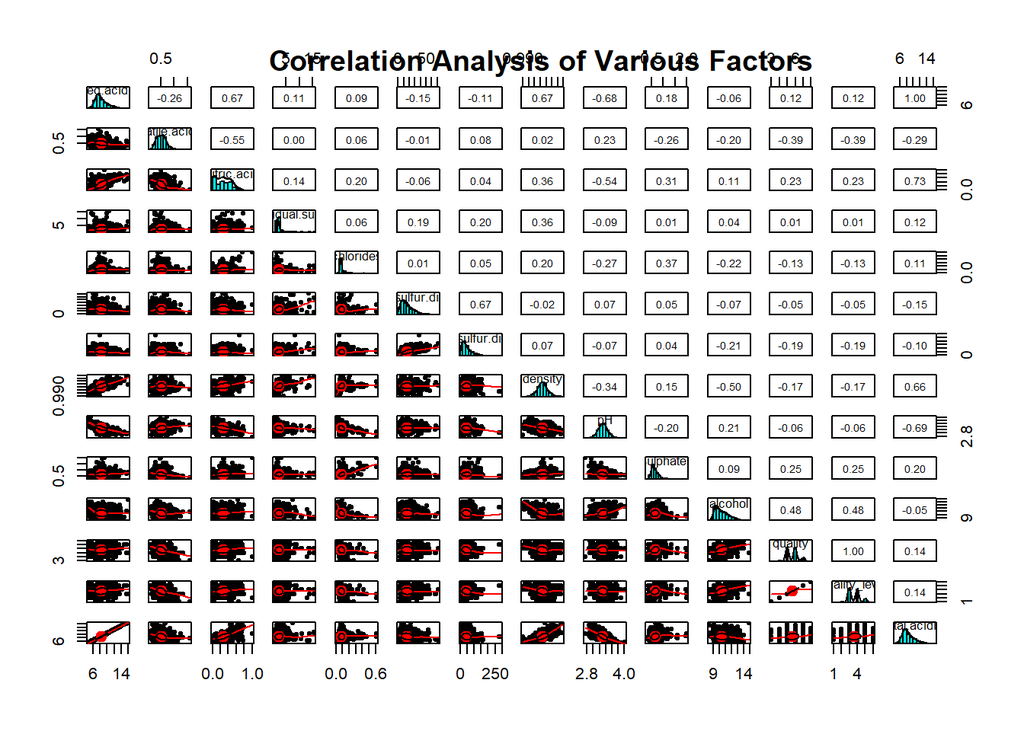

```
## integer(0)
```

### Description One

通过散点矩阵进行两两相关性分析，主要考察红酒品质和其它要素的关系。

发现：

（1）酒精、醋酸相关性较高，分别为0.48、-0.39，表明与红酒品质有较为明显的相关性。酒精是正相关，醋酸是负相关。

（2）硫酸盐、柠檬酸相关性次高，分别是0.25、0.23，表明与红酒品质有一定的相关性。均是正相关。

（3）其它要素相对性较低，绝对值均低于0.2，表明与红酒品质相关性较弱。

## 8.2 关于红酒质量分的形成猜测：基本分+微调

值得一提的是，由于各因素与质量分的相关性均不太高，我尝试通过缩小样本范围、建立新指标等方法对相关性进行改善，但效果并不理想。

因此，提出了一个关于该项目红酒质量分形成方式的合理猜测：即专家在打分前心里已经有了5或6分的基本预期，再根据口感和个人喜好进行微调。

基于上述猜测，我调整了数据探索思路，转而研究专家对极品酒的识别关键因素。

## 8.3 识别极品酒（极好或极坏），主要依靠醋酸、酒精、硫酸盐、盐

### Plot Two

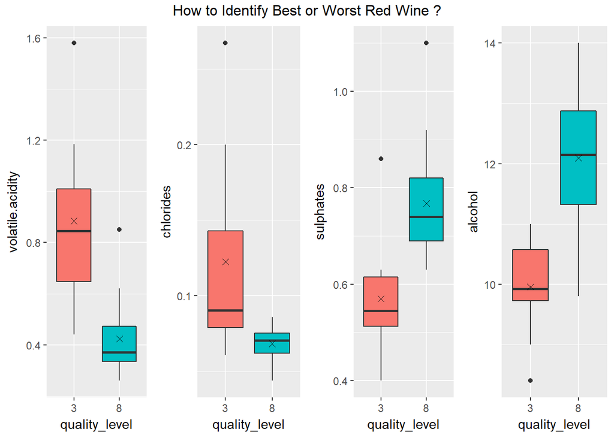

## Description Two

通过对红酒中极好和极差的酒进行比较分析，运用散点矩阵发现醋酸、酒精、硫酸盐、盐是决定好坏的根本性因素。

对这四个因素进行分类比较，发现好酒与坏酒在此方面具有明显的离散性，两者差异极其明显。

这四个因素很可能在专家打分中起到了木桶的“短板作用”。也就是说，有一个基本分打底，通过上述四个方面的短板，能够马上判断出好酒或坏酒。

## 8.4 醋酸、酒精、硫酸盐和红酒质量的关系

通过对整体红酒的分析、极品红酒的分析，找到了三个共同因素：醋酸、酒精、硫酸盐。

而柠檬酸的分布仔细分析，其实是很奇怪的，而且相关性也并不高；盐则更多作为一种短板因素，一旦出现即可判断极品酒，但对于整体性分析并不适用。以上两个因素，均不宜作为分析的关键因素。

### Plot Three

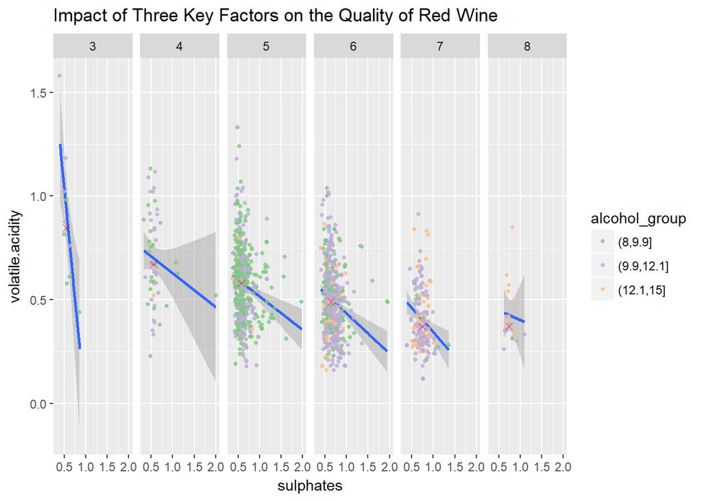

# 9 Reflection

## 9.1 主要经验：

（1）按照单变量分析、双变量分析、多变量分析的步骤全程走下来后，发现对数据有了深刻理解，发现了很多难以注意到的细节。  
（2）提出了一个猜测，作为分析的基础。在EDA过程中，提出很多小问题，为后续深入的正式分析提供了基础。

## 9.2 不足之处：

（1）对如何提升相关性，没有掌握很好的套路。或者说对于如何抓出特征变量，没有很好的办法。  
（2）没有进行数据独立性分析。  
（3）没有建立预测模型，考虑可以通过机器学习的方式，建立特征模型并实现预测打分。

## 9.3 请教reviewer几个问题：

（1）数学问题：在单变量分析中，有的指标取log后转换为接近正态分布，有什么意义？在后面的分析中如何使用？  
（2）技巧问题：在Final的图3中，为了绘制分面图中的红X，专门新建了一个数据集，是否有必要？有没有更简单的通过参数设置的方法达到同样的效果？  
（3）解释问题：在Final的图3中，提到了斜率的意义，我不确定是否这种解释是否正确。此外，如何解释图中lm估计的阴影部分？  
（4）技巧问题：如何在R中让图更加美观？重点是设置哪些方面的参数？有没有什么套路？在针对散点矩阵、分面、grid组合图中，如何让图更美观？  
（5）方法问题：如何进行数据的独立性分析？